# MTH3073 Final Project - What makes a song popular on Spotify?

By Sean Lovullo and Jake Bell

```r
library(spotifyr)
library(reticulate)
library(tidyverse)
```

## Part I: Introduction

Spotify is one of the largest media streaming services, with over 50 million songs available and over 250 million monthly users. How does Spotify offer song suggestions to its users? It generates data on every song over multiple categories and uses them to find songs to suggest based on what you like. Publicly accessible features include song length, key, mode, time signature, acousticness, danceability, energy, instrumentalness, liveness, loudness, speechiness, valence, and tempo. Pooling data that is publicly available, we want to answer the following question: can we predict the number of streams a Top 200 song on Spotify will get by finding clusters within the data that are based on the given audio features?

To find an answer, we will utilize the K-Means clustering algorithm to cluster the top 200 tracks into groups based on Spotify’s audio features. Then we will construct a number multiple regression models; there will be one for each cluster and also one ignoring the clusters. We will train the models using 80% of our data and test the models with the remaining 20% to see how well the model fits new data.

To accomplish these tasks, we will use both R and Python. R will be utilized to generate the data set in real-time, to do much of the data wrangling, and to visualize and model the data. Python (particularly the sci-kit learn package) is used to run the K-Means algorithm to cluster the data, as well as preparing the data to be used in that algorithm.

## Part II: Data Retrieval from Online Sources

The exact data set we have was not found on a public website. Instead, we stitched it together using Spotify’s publicly available top 200 song data, as well as using their API service to collect audio features for each track.

```r
# Gets current top 200 songs from Spotify
chart_data <- read_csv(
  url("https://spotifycharts.com/regional/global/daily/latest/download"),
  skip = 1,
  col_types = cols(
    col_integer(),
    col_character(),
    col_character(),
    col_integer(),
    col_character()
  )
) %>%
# The ".{22}$" is the regular expression used to extract the ID from the track URL
mutate(id = str_extract(URL, ".{22}$"))

head(chart_data,10)
```

| Position | Track Name | Artist | Streams | URL | id |
| --- | --- | --- | --- | --- | --- |
| 1 | DÁKITI | Bad Bunny | 6679357 | https://open.spotify.com/track/4MzXwWMhyBbmu6hOcLVD49 | 4MzXwWMhyBbmu6hOcLVD49 |
| 2 | Blinding Lights | The Weeknd | 4362106 | https://open.spotify.com/track/0VjIjW4GlUZAMYd2vXMi3b | 0VjIjW4GlUZAMYd2vXMi3b |
| 3 | positions | Ariana Grande | 4190410 | https://open.spotify.com/track/35mvY5S1H3J2QZyna3TFe0 | 35mvY5S1H3J2QZyna3TFe0 |
| 4 | All I Want for Christmas Is You | Mariah Carey | 4074896 | https://open.spotify.com/track/0bYg9bo50gSsH3LtXe2SQn | 0bYg9bo50gSsH3LtXe2SQn |
| 5 | Mood (feat. iann dior) | 24kGoldn | 3881783 | https://open.spotify.com/track/3tjFYV6RSFtuktYl3ZtYcq | 3tjFYV6RSFtuktYl3ZtYcq |
| 6 | LA NOCHE DE ANOCHE | Bad Bunny | 3740985 | https://open.spotify.com/track/2XIc1pqjXV3Cr2BQUGNBck | 2XIc1pqjXV3Cr2BQUGNBck |
| 7 | Dynamite | BTS | 3525308 | https://open.spotify.com/track/4saklk6nie3yiGePpBwUoc | 4saklk6nie3yiGePpBwUoc |
| 8 | Last Christmas | Wham! | 3419160 | https://open.spotify.com/track/2FRnf9qhLbvw8fu4IBXx78 | 2FRnf9qhLbvw8fu4IBXx78 |
| 9 | Therefore I Am | Billie Eilish | 3400606 | https://open.spotify.com/track/54bFM56PmE4YLRnqpW6Tha | 54bFM56PmE4YLRnqpW6Tha |
| 10 | BICHOTA | KAROL G | 3266985 | https://open.spotify.com/track/7vrJn5hDSXRmdXoR30KgF1 | 7vrJn5hDSXRmdXoR30KgF1 |

We first download the latest top 200 songs from Spotify as a csv file and extracted the song IDs from the URLs given.

```r
# Uses Spotify API to get track audio features for each track
track_feautres <- lapply(chart_data$id, FUN = "get_track_audio_features") %>% bind_rows() %>%
  select(id, everything())
head(track_feautres,10)
```

| id | danceability | energy | key | loudness | mode | speechiness | acousticness | instrumentalness | liveness | valence | tempo | type | uri | track_href | analysis_url | duration_ms | time_signature |
| --- | --- | --- | --- | --- | --- | --- | --- | --- | --- | --- | --- | --- | --- | --- | --- | --- | --- |
| 4MzXwWMhyBbmu6hOcLVD49 | 0.731 | 0.573 | 4 | -10.059 | 0 | 0.0544 | 0.40100 | 5.22e-05 | 0.1130 | 0.145 | 109.928 | audio_features | spotify:track:4MzXwWMhyBbmu6hOcLVD49 | https://api.spotify.com/v1/tracks/4MzXwWMhyBbmu6hOcLVD49 | https://api.spotify.com/v1/audio-analysis/4MzXwWMhyBbmu6hOcLVD49 | 205090 | 4 |
| 0VjIjW4GlUZAMYd2vXMi3b | 0.514 | 0.730 | 1 | -5.934 | 1 | 0.0598 | 0.00146 | 9.54e-05 | 0.0897 | 0.334 | 171.005 | audio_features | spotify:track:0VjIjW4GlUZAMYd2vXMi3b | https://api.spotify.com/v1/tracks/0VjIjW4GlUZAMYd2vXMi3b | https://api.spotify.com/v1/audio-analysis/0VjIjW4GlUZAMYd2vXMi3b | 200040 | 4 |
| 35mvY5S1H3J2QZyna3TFe0 | 0.737 | 0.802 | 0 | -4.771 | 1 | 0.0878 | 0.46800 | 0.00e+00 | 0.0931 | 0.682 | 144.015 | audio_features | spotify:track:35mvY5S1H3J2QZyna3TFe0 | https://api.spotify.com/v1/tracks/35mvY5S1H3J2QZyna3TFe0 | https://api.spotify.com/v1/audio-analysis/35mvY5S1H3J2QZyna3TFe0 | 172325 | 4 |
| 0bYg9bo50gSsH3LtXe2SQn | 0.336 | 0.627 | 7 | -7.463 | 1 | 0.0384 | 0.16400 | 0.00e+00 | 0.0708 | 0.350 | 150.273 | audio_features | spotify:track:0bYg9bo50gSsH3LtXe2SQn | https://api.spotify.com/v1/tracks/0bYg9bo50gSsH3LtXe2SQn | https://api.spotify.com/v1/audio-analysis/0bYg9bo50gSsH3LtXe2SQn | 241107 | 4 |
| 3tjFYV6RSFtuktYl3ZtYcq | 0.700 | 0.722 | 7 | -3.558 | 0 | 0.0369 | 0.22100 | 0.00e+00 | 0.2720 | 0.756 | 90.989 | audio_features | spotify:track:3tjFYV6RSFtuktYl3ZtYcq | https://api.spotify.com/v1/tracks/3tjFYV6RSFtuktYl3ZtYcq | https://api.spotify.com/v1/audio-analysis/3tjFYV6RSFtuktYl3ZtYcq | 140526 | 4 |
| 2XIc1pqjXV3Cr2BQUGNBck | 0.856 | 0.618 | 7 | -4.892 | 1 | 0.2860 | 0.03030 | 0.00e+00 | 0.0866 | 0.391 | 81.993 | audio_features | spotify:track:2XIc1pqjXV3Cr2BQUGNBck | https://api.spotify.com/v1/tracks/2XIc1pqjXV3Cr2BQUGNBck | https://api.spotify.com/v1/audio-analysis/2XIc1pqjXV3Cr2BQUGNBck | 203201 | 4 |
| 4saklk6nie3yiGePpBwUoc | 0.746 | 0.765 | 6 | -4.410 | 0 | 0.0993 | 0.01120 | 0.00e+00 | 0.0936 | 0.737 | 114.044 | audio_features | spotify:track:4saklk6nie3yiGePpBwUoc | https://api.spotify.com/v1/tracks/4saklk6nie3yiGePpBwUoc | https://api.spotify.com/v1/audio-analysis/4saklk6nie3yiGePpBwUoc | 199054 | 4 |
| 2FRnf9qhLbvw8fu4IBXx78 | 0.735 | 0.478 | 2 | -12.472 | 1 | 0.0293 | 0.18900 | 2.48e-06 | 0.3550 | 0.947 | 107.682 | audio_features | spotify:track:2FRnf9qhLbvw8fu4IBXx78 | https://api.spotify.com/v1/tracks/2FRnf9qhLbvw8fu4IBXx78 | https://api.spotify.com/v1/audio-analysis/2FRnf9qhLbvw8fu4IBXx78 | 262960 | 4 |
| 54bFM56PmE4YLRnqpW6Tha | 0.889 | 0.340 | 11 | -7.773 | 0 | 0.0697 | 0.21800 | 1.30e-01 | 0.0550 | 0.716 | 94.009 | audio_features | spotify:track:54bFM56PmE4YLRnqpW6Tha | https://api.spotify.com/v1/tracks/54bFM56PmE4YLRnqpW6Tha | https://api.spotify.com/v1/audio-analysis/54bFM56PmE4YLRnqpW6Tha | 174321 | 4 |
| 7vrJn5hDSXRmdXoR30KgF1 | 0.863 | 0.666 | 1 | -4.158 | 0 | 0.1520 | 0.21200 | 4.93e-04 | 0.1030 | 0.838 | 163.908 | audio_features | spotify:track:7vrJn5hDSXRmdXoR30KgF1 | https://api.spotify.com/v1/tracks/7vrJn5hDSXRmdXoR30KgF1 | https://api.spotify.com/v1/audio-analysis/7vrJn5hDSXRmdXoR30KgF1 | 178947 | 4 |

Next, we use the Spotify API (through the spotifyr wrapper package) to get the audio features of each of the tracks in our table. Many of the metrics Spotify has defined, such as danceability, energy, speechiness, etc. However, some of the metrics are more “concrete”, such as key, mode, tempo, duration_ms, and time signature. After getting the data for each track (stored in a separate table), we need to put the data together into a single data set.

```r
# joins the tables together to create the main data set for the project
top_200 <- left_join(chart_data, track_feautres, by = "id")
head(top_200,10)
```

| Position | Track Name | Artist | Streams | URL | id | danceability | energy | key | loudness | mode | speechiness | acousticness | instrumentalness | liveness | valence | tempo | type | uri | track_href | analysis_url | duration_ms | time_signature |
| --- | --- | --- | --- | --- | --- | --- | --- | --- | --- | --- | --- | --- | --- | --- | --- | --- | --- | --- | --- | --- | --- | --- |
| 1 | DÁKITI | Bad Bunny | 6679357 | https://open.spotify.com/track/4MzXwWMhyBbmu6hOcLVD49 | 4MzXwWMhyBbmu6hOcLVD49 | 0.731 | 0.573 | 4 | -10.059 | 0 | 0.0544 | 0.40100 | 5.22e-05 | 0.1130 | 0.145 | 109.928 | audio_features | spotify:track:4MzXwWMhyBbmu6hOcLVD49 | https://api.spotify.com/v1/tracks/4MzXwWMhyBbmu6hOcLVD49 | https://api.spotify.com/v1/audio-analysis/4MzXwWMhyBbmu6hOcLVD49 | 205090 | 4 |
| 2 | Blinding Lights | The Weeknd | 4362106 | https://open.spotify.com/track/0VjIjW4GlUZAMYd2vXMi3b | 0VjIjW4GlUZAMYd2vXMi3b | 0.514 | 0.730 | 1 | -5.934 | 1 | 0.0598 | 0.00146 | 9.54e-05 | 0.0897 | 0.334 | 171.005 | audio_features | spotify:track:0VjIjW4GlUZAMYd2vXMi3b | https://api.spotify.com/v1/tracks/0VjIjW4GlUZAMYd2vXMi3b | https://api.spotify.com/v1/audio-analysis/0VjIjW4GlUZAMYd2vXMi3b | 200040 | 4 |
| 3 | positions | Ariana Grande | 4190410 | https://open.spotify.com/track/35mvY5S1H3J2QZyna3TFe0 | 35mvY5S1H3J2QZyna3TFe0 | 0.737 | 0.802 | 0 | -4.771 | 1 | 0.0878 | 0.46800 | 0.00e+00 | 0.0931 | 0.682 | 144.015 | audio_features | spotify:track:35mvY5S1H3J2QZyna3TFe0 | https://api.spotify.com/v1/tracks/35mvY5S1H3J2QZyna3TFe0 | https://api.spotify.com/v1/audio-analysis/35mvY5S1H3J2QZyna3TFe0 | 172325 | 4 |
| 4 | All I Want for Christmas Is You | Mariah Carey | 4074896 | https://open.spotify.com/track/0bYg9bo50gSsH3LtXe2SQn | 0bYg9bo50gSsH3LtXe2SQn | 0.336 | 0.627 | 7 | -7.463 | 1 | 0.0384 | 0.16400 | 0.00e+00 | 0.0708 | 0.350 | 150.273 | audio_features | spotify:track:0bYg9bo50gSsH3LtXe2SQn | https://api.spotify.com/v1/tracks/0bYg9bo50gSsH3LtXe2SQn | https://api.spotify.com/v1/audio-analysis/0bYg9bo50gSsH3LtXe2SQn | 241107 | 4 |
| 5 | Mood (feat. iann dior) | 24kGoldn | 3881783 | https://open.spotify.com/track/3tjFYV6RSFtuktYl3ZtYcq | 3tjFYV6RSFtuktYl3ZtYcq | 0.700 | 0.722 | 7 | -3.558 | 0 | 0.0369 | 0.22100 | 0.00e+00 | 0.2720 | 0.756 | 90.989 | audio_features | spotify:track:3tjFYV6RSFtuktYl3ZtYcq | https://api.spotify.com/v1/tracks/3tjFYV6RSFtuktYl3ZtYcq | https://api.spotify.com/v1/audio-analysis/3tjFYV6RSFtuktYl3ZtYcq | 140526 | 4 |
| 6 | LA NOCHE DE ANOCHE | Bad Bunny | 3740985 | https://open.spotify.com/track/2XIc1pqjXV3Cr2BQUGNBck | 2XIc1pqjXV3Cr2BQUGNBck | 0.856 | 0.618 | 7 | -4.892 | 1 | 0.2860 | 0.03030 | 0.00e+00 | 0.0866 | 0.391 | 81.993 | audio_features | spotify:track:2XIc1pqjXV3Cr2BQUGNBck | https://api.spotify.com/v1/tracks/2XIc1pqjXV3Cr2BQUGNBck | https://api.spotify.com/v1/audio-analysis/2XIc1pqjXV3Cr2BQUGNBck | 203201 | 4 |
| 7 | Dynamite | BTS | 3525308 | https://open.spotify.com/track/4saklk6nie3yiGePpBwUoc | 4saklk6nie3yiGePpBwUoc | 0.746 | 0.765 | 6 | -4.410 | 0 | 0.0993 | 0.01120 | 0.00e+00 | 0.0936 | 0.737 | 114.044 | audio_features | spotify:track:4saklk6nie3yiGePpBwUoc | https://api.spotify.com/v1/tracks/4saklk6nie3yiGePpBwUoc | https://api.spotify.com/v1/audio-analysis/4saklk6nie3yiGePpBwUoc | 199054 | 4 |
| 8 | Last Christmas | Wham! | 3419160 | https://open.spotify.com/track/2FRnf9qhLbvw8fu4IBXx78 | 2FRnf9qhLbvw8fu4IBXx78 | 0.735 | 0.478 | 2 | -12.472 | 1 | 0.0293 | 0.18900 | 2.48e-06 | 0.3550 | 0.947 | 107.682 | audio_features | spotify:track:2FRnf9qhLbvw8fu4IBXx78 | https://api.spotify.com/v1/tracks/2FRnf9qhLbvw8fu4IBXx78 | https://api.spotify.com/v1/audio-analysis/2FRnf9qhLbvw8fu4IBXx78 | 262960 | 4 |
| 9 | Therefore I Am | Billie Eilish | 3400606 | https://open.spotify.com/track/54bFM56PmE4YLRnqpW6Tha | 54bFM56PmE4YLRnqpW6Tha | 0.889 | 0.340 | 11 | -7.773 | 0 | 0.0697 | 0.21800 | 1.30e-01 | 0.0550 | 0.716 | 94.009 | audio_features | spotify:track:54bFM56PmE4YLRnqpW6Tha | https://api.spotify.com/v1/tracks/54bFM56PmE4YLRnqpW6Tha | https://api.spotify.com/v1/audio-analysis/54bFM56PmE4YLRnqpW6Tha | 174321 | 4 |
| 10 | BICHOTA | KAROL G | 3266985 | https://open.spotify.com/track/7vrJn5hDSXRmdXoR30KgF1 | 7vrJn5hDSXRmdXoR30KgF1 | 0.863 | 0.666 | 1 | -4.158 | 0 | 0.1520 | 0.21200 | 4.93e-04 | 0.1030 | 0.838 | 163.908 | audio_features | spotify:track:7vrJn5hDSXRmdXoR30KgF1 | https://api.spotify.com/v1/tracks/7vrJn5hDSXRmdXoR30KgF1 | https://api.spotify.com/v1/audio-analysis/7vrJn5hDSXRmdXoR30KgF1 | 178947 | 4 |

It is with this data set that we will answer our question. Next, we will be moving over to Python to utilize the k-means clustering algorithm in the sci-kit learn package.

## Part III: Clustering

First, we’ll be importing all the packages at once to get it all out of the way.

```python
#import statements
import numpy as np
import pandas as pd
import matplotlib.pyplot as plt

from sklearn.model_selection import train_test_split
from sklearn.cluster import KMeans

from sklearn.metrics import silhouette_score
from sklearn.preprocessing import StandardScaler
```

Next, we need to bring our data into our Python environment.

```
track_data = r.track_data
track_data.head(10)
```

```
   Position                       Track Name  ... duration_ms  time_signature
0         1                           D挼㸱KITI  ...      205090               4
1         2                  Blinding Lights  ...      200040               4
2         3                        positions  ...      172325               4
3         4  All I Want for Christmas Is You  ...      241107               4
4         5           Mood (feat. iann dior)  ...      140526               4
5         6               LA NOCHE DE ANOCHE  ...      203201               4
6         7                         Dynamite  ...      199054               4
7         8                   Last Christmas  ...      262960               4
8         9                   Therefore I Am  ...      174321               4
9        10                          BICHOTA  ...      178947               4

[10 rows x 23 columns]
```

To use the k-means clustering algorithm, we want to choose which variables to use for clustering, create a subset of the main data set containing them, and then standardize those variables so that their ranges are scaled and have unit standard deviations ($\sigma$ = 1).

```
#Now we will create a subset of x predictor values for use in the K-Means algorithm
subset_reg = track_data.loc[:,['danceability','energy','valence','tempo', 'mode']]

#Standardize the variables so we can use them all (z-scores)
subset = StandardScaler().fit_transform(subset_reg)
subset = pd.DataFrame(data = subset, columns = subset_reg.columns.values)

subset.head(10)
```

```
   danceability    energy   valence     tempo      mode
0      0.348840 -0.246609 -1.745987 -0.398934 -1.105542
1     -1.141872  0.718797 -0.910074  1.613247  0.904534
2      0.390058  1.161531  0.629069  0.724062  0.904534
3     -2.364668  0.085442 -0.839308  0.930232  0.904534
4      0.135881  0.669605  0.956358 -1.022880 -1.105542
5      1.207545  0.030100 -0.657973 -1.319253  0.904534
6      0.451885  0.934015  0.872325 -0.263333 -1.105542
7      0.376319 -0.830772  1.801118 -0.472929  0.904534
8      1.434243 -1.679346  0.779445 -0.923386 -1.105542
9      1.255633  0.325256  1.319030  1.379437 -1.105542
```

When using k-means for clustering, we must pick the number of clusters; the algorithm does not tell us what the optimal number is. However, we can make a better decision by comparing inertia values and silhouette scores. The following code generates these values for various values of k.

```
#test K-means with different cluster sizes (1-8) to find the inertia and silhouette scores
results1 = {}
results2 = {}
for k in range(1,8):
  kmeans = KMeans(n_clusters=k)
  kmeans.fit_predict(subset)
  inertia = kmeans.inertia_
  colName = str(k)
  results1.update({colName: inertia})

  if (k > 1):
    s_score = silhouette_score(subset, kmeans.labels_)
    results2.update({colName: s_score})

results1 = pd.DataFrame(
    list(results1.items()),
    columns = ['K','Inertia']
)
results2 = pd.DataFrame(
    list(results2.items()),
    columns = ['K', 'Silhouette Score']
)
```

The results for inertia and silhouette scores for various values of k are as follows:

```
   K      Inertia
0  1  1000.000000
1  2   768.076944
2  3   605.061705
3  4   528.578520
4  5   474.071995
5  6   429.101139
6  7   396.142375
```

```
   K  Silhouette Score
0  2          0.246024
1  3          0.256733
2  4          0.251836
3  5          0.225055
4  6          0.225814
5  7          0.225756
```

With those values, let’s visualize our results so that we can interpret them.

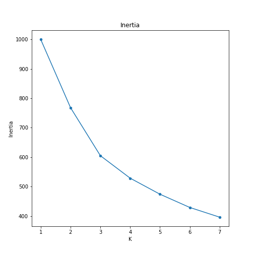

```python
#graph inertia scores
ax = plt.gca()
results1.plot(x = 'K', y ='Inertia', kind = 'line', ax = ax)
results1.plot(x = 'K', y = 'Inertia', kind = 'scatter', ax= ax)
ax.get_legend().remove()
plt.title("Inertia")
#plt.show()
```

For our inertia plot, we are looking for an “elbow,” or for which value of k the graph bends most. The best point to call an elbow appears to be $k=3$. Because the elbow is not so clear or defined, let’s now look at the silhouette scores and compare those.

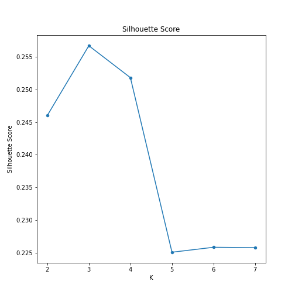

```python
#graph silhouette scores to pick the best num of clusters
ax = plt.gca()
results2.plot(x = 'K', y = 'Silhouette Score', kind = 'line', ax = ax)
results2.plot(x = 'K', y = 'Silhouette Score', kind = 'scatter', ax = ax)
ax.get_legend().remove()
plt.title("Silhouette Score")
#plt.show()
```

We are looking for the highest value for our silhouette score. We can see that our highest value is when $k=3$. Thus, based on our evidence, we will choose $k=3$ when we run the k-means clustering algorithm.

```
#run KMeans algorithm, picking num. clusters = 3, since it is a good elbow for inertia graph
k = 3
init_pos = np.array([
  [-1.414612,-1.175720,-1.155611,-0.691465,0.233730],
  [0.493033,0.298614,0.162068,0.089535,-1.151339],
  [0.139266,0.208380,0.314348,0.194291,0.868554]
])
kmeans= KMeans(n_clusters = k, init=init_pos, n_init=1)
y_pred = kmeans.fit_predict(subset)

pd.DataFrame(y_pred).head(10) #look at the labels
```

```
   0
0  1
1  2
2  2
3  0
4  1
5  2
6  1
7  2
8  1
9  1
```

Here, we see the first 10 results for when we use k-means on our data for when $k=3$.

The cluster a track is assigned to is based on what centroid it is closest to. Given that it is difficult to visualize a 5D space, below are the 5D coordinates for each of the centroids.

```
#look at centroids
centroids = kmeans.cluster_centers_
pd.DataFrame(centroids, columns = subset_reg.columns.values)
```

```
   danceability    energy   valence     tempo      mode
0     -1.408171 -1.218707 -1.192341 -0.723300  0.195096
1      0.437089  0.283079  0.158515  0.142866 -1.105542
2      0.156647  0.219953  0.320175  0.152826  0.904534
```

Now that we have a list of clutsers, we need to join it back to our original data set, and then split our data into testing and training sets for each category to train and test the models.

```
id_list = list(subset.index)
IDs = pd.DataFrame({'ID':id_list})
to_join = IDs.join(pd.DataFrame({'cluster':y_pred}))
to_join = to_join.set_index('ID')
track_data = track_data.join(to_join)
track_data.head(10)
```

```
   Position                       Track Name  ... time_signature  cluster
0         1                           D挼㸱KITI  ...              4        1
1         2                  Blinding Lights  ...              4        2
2         3                        positions  ...              4        2
3         4  All I Want for Christmas Is You  ...              4        0
4         5           Mood (feat. iann dior)  ...              4        1
5         6               LA NOCHE DE ANOCHE  ...              4        2
6         7                         Dynamite  ...              4        1
7         8                   Last Christmas  ...              4        2
8         9                   Therefore I Am  ...              4        1
9        10                          BICHOTA  ...              4        1

[10 rows x 24 columns]
```

```python
# creates filtered data sets
c0_data = track_data[track_data['cluster']==0]
c1_data = track_data[track_data['cluster']==1]
c2_data = track_data[track_data['cluster']==2]

# splits each of the filtered data sets into a 80/20 train/test split
train_c0, test_c0 = train_test_split(c0_data, test_size=0.2)
train_c1, test_c1 = train_test_split(c1_data, test_size=0.2)
train_c2, test_c2 = train_test_split(c2_data, test_size=0.2)
```

Using the k-means clustering algorithm from Python’s sci-kit learn package, we have assigned each track a group based upon its audio characteristics. Next, we will create models with R that try to predict the number of streams a track will get.

## Part IV: Modeling

First, let’s bring our data back over to R.

```r
track_data <- py$track_data %>%
  mutate(cluster = as.factor(cluster))
track_data %>% head(10)
```

|  | Position | Track Name | Artist | Streams | URL | id | danceability | energy | key | loudness | mode | speechiness | acousticness | instrumentalness | liveness | valence | tempo | type | uri | track_href | analysis_url | duration_ms | time_signature | cluster |
| --- | --- | --- | --- | --- | --- | --- | --- | --- | --- | --- | --- | --- | --- | --- | --- | --- | --- | --- | --- | --- | --- | --- | --- | --- |
| 1 | 1 | DÁKITI | Bad Bunny | 6679357 | https://open.spotify.com/track/4MzXwWMhyBbmu6hOcLVD49 | 4MzXwWMhyBbmu6hOcLVD49 | 0.731 | 0.573 | 4 | -10.059 | 0 | 0.0544 | 0.40100 | 5.22e-05 | 0.1130 | 0.145 | 109.928 | audio_features | spotify:track:4MzXwWMhyBbmu6hOcLVD49 | https://api.spotify.com/v1/tracks/4MzXwWMhyBbmu6hOcLVD49 | https://api.spotify.com/v1/audio-analysis/4MzXwWMhyBbmu6hOcLVD49 | 205090 | 4 | 1 |
| 2 | 2 | Blinding Lights | The Weeknd | 4362106 | https://open.spotify.com/track/0VjIjW4GlUZAMYd2vXMi3b | 0VjIjW4GlUZAMYd2vXMi3b | 0.514 | 0.730 | 1 | -5.934 | 1 | 0.0598 | 0.00146 | 9.54e-05 | 0.0897 | 0.334 | 171.005 | audio_features | spotify:track:0VjIjW4GlUZAMYd2vXMi3b | https://api.spotify.com/v1/tracks/0VjIjW4GlUZAMYd2vXMi3b | https://api.spotify.com/v1/audio-analysis/0VjIjW4GlUZAMYd2vXMi3b | 200040 | 4 | 2 |
| 3 | 3 | positions | Ariana Grande | 4190410 | https://open.spotify.com/track/35mvY5S1H3J2QZyna3TFe0 | 35mvY5S1H3J2QZyna3TFe0 | 0.737 | 0.802 | 0 | -4.771 | 1 | 0.0878 | 0.46800 | 0.00e+00 | 0.0931 | 0.682 | 144.015 | audio_features | spotify:track:35mvY5S1H3J2QZyna3TFe0 | https://api.spotify.com/v1/tracks/35mvY5S1H3J2QZyna3TFe0 | https://api.spotify.com/v1/audio-analysis/35mvY5S1H3J2QZyna3TFe0 | 172325 | 4 | 2 |
| 4 | 4 | All I Want for Christmas Is You | Mariah Carey | 4074896 | https://open.spotify.com/track/0bYg9bo50gSsH3LtXe2SQn | 0bYg9bo50gSsH3LtXe2SQn | 0.336 | 0.627 | 7 | -7.463 | 1 | 0.0384 | 0.16400 | 0.00e+00 | 0.0708 | 0.350 | 150.273 | audio_features | spotify:track:0bYg9bo50gSsH3LtXe2SQn | https://api.spotify.com/v1/tracks/0bYg9bo50gSsH3LtXe2SQn | https://api.spotify.com/v1/audio-analysis/0bYg9bo50gSsH3LtXe2SQn | 241107 | 4 | 0 |
| 5 | 5 | Mood (feat. iann dior) | 24kGoldn | 3881783 | https://open.spotify.com/track/3tjFYV6RSFtuktYl3ZtYcq | 3tjFYV6RSFtuktYl3ZtYcq | 0.700 | 0.722 | 7 | -3.558 | 0 | 0.0369 | 0.22100 | 0.00e+00 | 0.2720 | 0.756 | 90.989 | audio_features | spotify:track:3tjFYV6RSFtuktYl3ZtYcq | https://api.spotify.com/v1/tracks/3tjFYV6RSFtuktYl3ZtYcq | https://api.spotify.com/v1/audio-analysis/3tjFYV6RSFtuktYl3ZtYcq | 140526 | 4 | 1 |
| 6 | 6 | LA NOCHE DE ANOCHE | Bad Bunny | 3740985 | https://open.spotify.com/track/2XIc1pqjXV3Cr2BQUGNBck | 2XIc1pqjXV3Cr2BQUGNBck | 0.856 | 0.618 | 7 | -4.892 | 1 | 0.2860 | 0.03030 | 0.00e+00 | 0.0866 | 0.391 | 81.993 | audio_features | spotify:track:2XIc1pqjXV3Cr2BQUGNBck | https://api.spotify.com/v1/tracks/2XIc1pqjXV3Cr2BQUGNBck | https://api.spotify.com/v1/audio-analysis/2XIc1pqjXV3Cr2BQUGNBck | 203201 | 4 | 2 |
| 7 | 7 | Dynamite | BTS | 3525308 | https://open.spotify.com/track/4saklk6nie3yiGePpBwUoc | 4saklk6nie3yiGePpBwUoc | 0.746 | 0.765 | 6 | -4.410 | 0 | 0.0993 | 0.01120 | 0.00e+00 | 0.0936 | 0.737 | 114.044 | audio_features | spotify:track:4saklk6nie3yiGePpBwUoc | https://api.spotify.com/v1/tracks/4saklk6nie3yiGePpBwUoc | https://api.spotify.com/v1/audio-analysis/4saklk6nie3yiGePpBwUoc | 199054 | 4 | 1 |
| 8 | 8 | Last Christmas | Wham! | 3419160 | https://open.spotify.com/track/2FRnf9qhLbvw8fu4IBXx78 | 2FRnf9qhLbvw8fu4IBXx78 | 0.735 | 0.478 | 2 | -12.472 | 1 | 0.0293 | 0.18900 | 2.48e-06 | 0.3550 | 0.947 | 107.682 | audio_features | spotify:track:2FRnf9qhLbvw8fu4IBXx78 | https://api.spotify.com/v1/tracks/2FRnf9qhLbvw8fu4IBXx78 | https://api.spotify.com/v1/audio-analysis/2FRnf9qhLbvw8fu4IBXx78 | 262960 | 4 | 2 |
| 9 | 9 | Therefore I Am | Billie Eilish | 3400606 | https://open.spotify.com/track/54bFM56PmE4YLRnqpW6Tha | 54bFM56PmE4YLRnqpW6Tha | 0.889 | 0.340 | 11 | -7.773 | 0 | 0.0697 | 0.21800 | 1.30e-01 | 0.0550 | 0.716 | 94.009 | audio_features | spotify:track:54bFM56PmE4YLRnqpW6Tha | https://api.spotify.com/v1/tracks/54bFM56PmE4YLRnqpW6Tha | https://api.spotify.com/v1/audio-analysis/54bFM56PmE4YLRnqpW6Tha | 174321 | 4 | 1 |
| 10 | 10 | BICHOTA | KAROL G | 3266985 | https://open.spotify.com/track/7vrJn5hDSXRmdXoR30KgF1 | 7vrJn5hDSXRmdXoR30KgF1 | 0.863 | 0.666 | 1 | -4.158 | 0 | 0.1520 | 0.21200 | 4.93e-04 | 0.1030 | 0.838 | 163.908 | audio_features | spotify:track:7vrJn5hDSXRmdXoR30KgF1 | https://api.spotify.com/v1/tracks/7vrJn5hDSXRmdXoR30KgF1 | https://api.spotify.com/v1/audio-analysis/7vrJn5hDSXRmdXoR30KgF1 | 178947 | 4 | 1 |

```r
# brings over all of the training and testing data sets from Python (and gets rid of the index columns from pandas)
# cluster is set as an integer for now to avoid errors when binding rows, although it will be a factor
train_c0 <- py$train_c0 %>%
  mutate(cluster = as.integer(cluster))
rownames(train_c0) <- NULL
test_c0 <- py$test_c0 %>%
  mutate(cluster = as.integer(cluster))
rownames(test_c0) <- NULL

train_c1 <- py$train_c1 %>%
  mutate(cluster = as.integer(cluster))
rownames(train_c1) <- NULL
test_c1 <- py$test_c1 %>%
  mutate(cluster = as.integer(cluster))
rownames(test_c1) <- NULL

train_c2 <- py$train_c2 %>%
  mutate(cluster = as.integer(cluster))
rownames(train_c2) <- NULL
test_c2 <- py$test_c2 %>%
  mutate(cluster = as.integer(cluster))
rownames(test_c2) <- NULL
```

```r
# joins all of the training data together into one data set
train_data <- train_c0 %>%
  bind_rows(train_c1) %>%
  bind_rows(train_c2) %>%
  mutate(cluster = as.factor(cluster))

# joins all of the testing data together into one data set
test_data <- test_c0 %>%
  bind_rows(test_c1) %>%
  bind_rows(test_c2) %>%
  mutate(cluster = as.factor(cluster))

# cluster is categorical, so the data type needs to be a factor in R to be handled properly
train_c0 <- train_c0 %>%
  mutate(cluster = as.factor(cluster))
test_c0 <- test_c0 %>%
  mutate(cluster = as.factor(cluster))

train_c1 <- train_c1 %>%
  mutate(cluster = as.factor(cluster))
test_c1 <- test_c1 %>%
  mutate(cluster = as.factor(cluster))

train_c2 <- train_c2 %>%
  mutate(cluster = as.factor(cluster))
test_c2 <- test_c2 %>%
  mutate(cluster = as.factor(cluster))
```

Now that we have finished preparing our data, I will restate the focus question: can we predict the number of streams a Top 200 song on Spotify will get by finding clusters within the data? We want to know if we can predict the number of streams a song will get by using the cluster a track belongs to. We will create a model for each cluster, as well as for the whole data set. How should we construct our models? To answer this question, let’s examine scatter plots of our predictors with our target, streams.

### Section A: Scatter plots

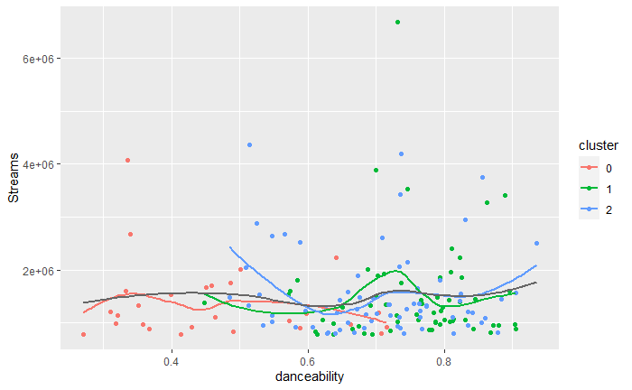

```r
ggplot(data = train_data, mapping = aes(y = Streams, x = danceability, color = cluster)) +
  geom_point() +
  geom_smooth(se = FALSE) +
  geom_smooth(se = FALSE, color = "gray40")
```

When using geom_smooth from ggplot2, it creates a line using the loess (local polynomial regression) method by default. Using these lines as a visual guide, we are able to get an idea what degree of polynomial regression to use for each variable and cluster combination.

#### Danceability

- Cluster 0: degree 4 polynomial
- Cluster 1: degree 4 polynomial
- Cluster 2: degree 4 polynomial
- None: degree 2 polynomial

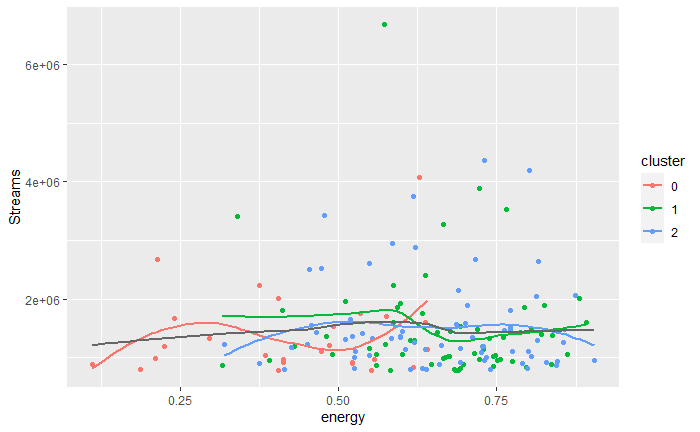

```r
ggplot(data = train_data, mapping = aes(y = Streams, x = energy, color = cluster)) +
  geom_point() +
  geom_smooth(se = FALSE) +
  geom_smooth(se = FALSE, color = "gray40")
```

#### Energy

- Cluster 0: degree 3 polynomial
- Cluster 1: degree 4 polynomial
- Cluster 2: degree 2 polynomial
- None: degree 2 polynomial

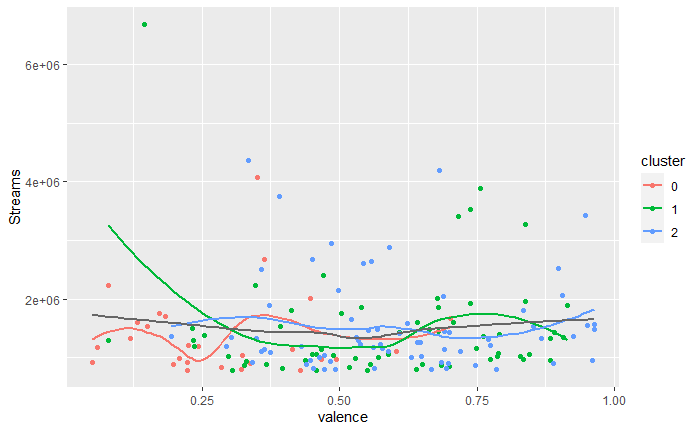

```r
ggplot(data = train_data, mapping = aes(y = Streams, x = valence, color = cluster)) +
  geom_point() +
  geom_smooth(se = FALSE) +
  geom_smooth(se = FALSE, color = "gray40")
```

#### Valence

- Cluster 0: degree 4 polynomial
- Cluster 1: degree 5 polynomial
- Cluster 2: degree 3 polynomial
- None: degree 4 polynomial

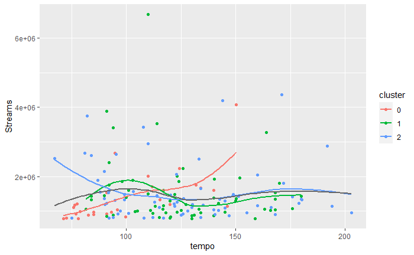

```r
ggplot(data = train_data, mapping = aes(y = Streams, x = tempo, color = cluster)) +
  geom_point() +
  geom_smooth(se = FALSE) +
  geom_smooth(se = FALSE, color = "gray40")
```

#### Tempo

- Cluster 0: degree 3 polynomial
- Cluster 1: degree 4 polynomial
- Cluster 2: degree 2 polynomial
- None: degree 3 polynomial

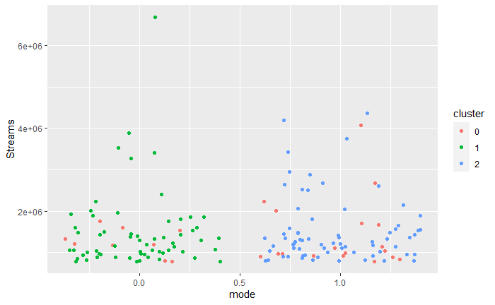

```r
ggplot(data = train_data, mapping = aes(y = Streams, x = mode, color = cluster)) +
  geom_jitter()
```

Mode is a categorical variable denoting whether a track is in a major (0) or minor (1) key. We intentionally used the geom_jitter object so that all of the data points could be seen. Otherwise, they would all be bunched into tight columns at 0 and 1, and many would not be seen.

We can see that two of the clusters are closely related to this categorical variable, although one cluster seems to be scattered between the two modes. The two categories have a similar shape, having a similar density (number of data points) and height (excluding the obvious outlier for mode 0). Thus, although this was used for clustering, it will not be included in the model, as this categorical variable would clearly not help to indicate the number of streams a track would get.

### Section B: Model Building

#### Cluster 0

We will construct a model for our first cluster, cluster 0

- Danceability - degree 4
- Energy - degree 3
- Valence - degree 4
- Tempo - degree 3

```r
c0.lm <- lm(
  Streams ~ poly(danceability,4) + poly(energy,3) + poly(valence,4) + poly(tempo,3),
  data = train_c0
)
summary(c0.lm)
```

```
Call:
lm(formula = Streams ~ poly(danceability, 4) + poly(energy, 3) +
    poly(valence, 4) + poly(tempo, 3), data = train_c0)

Residuals:
     Min       1Q   Median       3Q      Max
-1190742  -283027    -7688   217659  1115926

Coefficients:
                       Estimate Std. Error t value Pr(>|t|)
(Intercept)             1377237     135896  10.135  3.1e-07 ***
poly(danceability, 4)1  -440495     911780  -0.483   0.6377
poly(danceability, 4)2  -258255     930198  -0.278   0.7860
poly(danceability, 4)3   282682     906045   0.312   0.7604
poly(danceability, 4)4    52799    1016447   0.052   0.9594
poly(energy, 3)1       -1197800    1164237  -1.029   0.3239
poly(energy, 3)2       -1520567    1079900  -1.408   0.1845
poly(energy, 3)3        -435196    1086510  -0.401   0.6958
poly(valence, 4)1       -223854     851357  -0.263   0.7971
poly(valence, 4)2       -714015     924393  -0.772   0.4548
poly(valence, 4)3        -35813     920836  -0.039   0.9696
poly(valence, 4)4         27239    1067538   0.026   0.9801
poly(tempo, 3)1         3364348    1158719   2.904   0.0132 *
poly(tempo, 3)2         1080436     984668   1.097   0.2941
poly(tempo, 3)3         1142346    1260842   0.906   0.3828
---
Signif. codes:  0 ‘***’ 0.001 ‘**’ 0.01 ‘*’ 0.05 ‘.’ 0.1 ‘ ’ 1

Residual standard error: 706100 on 12 degrees of freedom
Multiple R-squared:  0.5574,    Adjusted R-squared:  0.04094
F-statistic: 1.079 on 14 and 12 DF,  p-value: 0.4523
```

The multiple R-squared is above 0.5 (if not, then likely near 0.5 based on the results of multiple runs of this code), but the adjusted R-squared is very small. Tempo typically seems to be the most significant predictor in this model. This cluster, based on the results of observed runs, always has had the highest multiple R-squared in comparison to the other models, which show similar results (as you will see below).

#### Cluster 1

Now we will construct a model for cluster 1

- Danceability - degree 4
- Energy - degree 4
- Valence - degree 5
- Tempo - degree 4

```r
c1.lm <- lm(
  Streams ~ poly(danceability,4) + poly(energy,4) + poly(valence,5) + poly(tempo,4),
  data = train_c1
)
summary(c1.lm)
```

```
Call:
lm(formula = Streams ~ poly(danceability, 4) + poly(energy, 4) +
    poly(valence, 5) + poly(tempo, 4), data = train_c1)

Residuals:
     Min       1Q   Median       3Q      Max
-1120387  -459331  -114369   359835  3119186

Coefficients:
                       Estimate Std. Error t value Pr(>|t|)
(Intercept)             1496557     116882  12.804   <2e-16 ***
poly(danceability, 4)1    37282    1079194   0.035   0.9726
poly(danceability, 4)2   158308     986951   0.160   0.8733
poly(danceability, 4)3   -18434    1048515  -0.018   0.9861
poly(danceability, 4)4   852246    1129448   0.755   0.4545
poly(energy, 4)1       -1949818    1135447  -1.717   0.0930 .
poly(energy, 4)2        -106307     993553  -0.107   0.9153
poly(energy, 4)3         851817    1069427   0.797   0.4300
poly(energy, 4)4         634885     986958   0.643   0.5234
poly(valence, 5)1        -37859    1137347  -0.033   0.9736
poly(valence, 5)2       2291924    1008373   2.273   0.0280 *
poly(valence, 5)3      -1534254     988427  -1.552   0.1278
poly(valence, 5)4      -1106618    1028956  -1.075   0.2880
poly(valence, 5)5       1075085    1200210   0.896   0.3753
poly(tempo, 4)1         -773346    1006880  -0.768   0.4466
poly(tempo, 4)2         1484395    1078504   1.376   0.1757
poly(tempo, 4)3         1792417    1185436   1.512   0.1377
poly(tempo, 4)4        -1650329     946587  -1.743   0.0882 .
---
Signif. codes:  0 ‘***’ 0.001 ‘**’ 0.01 ‘*’ 0.05 ‘.’ 0.1 ‘ ’ 1

Residual standard error: 920300 on 44 degrees of freedom
Multiple R-squared:  0.3306,    Adjusted R-squared:  0.07196
F-statistic: 1.278 on 17 and 44 DF,  p-value: 0.2506
```

Our results show a low multiple R-squared and a (more often than not) negative adjusted R-squared. The model appears to be a poor fit, and its results are similar to that of cluster 2 and when there are no clusters.

#### Cluster 2

Next is the model for cluster 2

- Danceability - degree 4
- Energy - degree 2
- Valence - degree 3
- Tempo - degree 2

```r
c2.lm <- lm(
  Streams ~ poly(danceability,4) + poly(energy,2) + poly(valence,3) + poly(tempo,2),
  data = train_c2
)
summary(c2.lm)
```

```
Call:
lm(formula = Streams ~ poly(danceability, 4) + poly(energy, 2) +
    poly(valence, 3) + poly(tempo, 2), data = train_c2)

Residuals:
     Min       1Q   Median       3Q      Max
-1307457  -390262  -160921   143412  2994258

Coefficients:
                       Estimate Std. Error t value Pr(>|t|)
(Intercept)             1531085      96610  15.848   <2e-16 ***
poly(danceability, 4)1  -461094     922839  -0.500   0.6192
poly(danceability, 4)2  1651772     871097   1.896   0.0629 .
poly(danceability, 4)3  -738932     838100  -0.882   0.3816
poly(danceability, 4)4  1080072     861261   1.254   0.2149
poly(energy, 2)1         -14254     890638  -0.016   0.9873
poly(energy, 2)2        -517039     906097  -0.571   0.5705
poly(valence, 3)1       -627859     927657  -0.677   0.5012
poly(valence, 3)2        126039     859693   0.147   0.8839
poly(valence, 3)3        181790     841925   0.216   0.8298
poly(tempo, 2)1         -929632     890486  -1.044   0.3008
poly(tempo, 2)2         1339879     901164   1.487   0.1425
---
Signif. codes:  0 ‘***’ 0.001 ‘**’ 0.01 ‘*’ 0.05 ‘.’ 0.1 ‘ ’ 1

Residual standard error: 808300 on 58 degrees of freedom
Multiple R-squared:  0.1509,    Adjusted R-squared:  -0.0101
F-statistic: 0.9373 on 11 and 58 DF,  p-value: 0.5122
```

As the results are the same as the cluster 1, a slightly modified version of the statement regarding cluster 1 is given below:

Once again, our results show a low multiple R-squared and a (more often than not) negative adjusted R-squared. The model appears to be a poor fit, and its results are similar to that of cluster 1 and when there are no clusters.

#### No Clusters

Lastly, we will construct a model for the entire training data set

- Danceability - degree 2
- Energy - degree 2
- Valence - degree 4
- Tempo - degree 3

```r
none.lm <- lm(
  Streams ~ poly(danceability,2) + poly(energy,2) + poly(valence,4) + poly(tempo,3),
  data = train_data
)
summary(none.lm)
```

```
Call:
lm(formula = Streams ~ poly(danceability, 2) + poly(energy, 2) +
    poly(valence, 4) + poly(tempo, 3), data = train_data)

Residuals:
    Min      1Q  Median      3Q     Max
-802384 -505298 -300017  107957 4944324

Coefficients:
                       Estimate Std. Error t value Pr(>|t|)
(Intercept)             1491496      69147  21.570   <2e-16 ***
poly(danceability, 2)1   -67694    1031499  -0.066    0.948
poly(danceability, 2)2   396671     919952   0.431    0.667
poly(energy, 2)1         341256    1010456   0.338    0.736
poly(energy, 2)2        -883336     916332  -0.964    0.337
poly(valence, 4)1         39728    1025198   0.039    0.969
poly(valence, 4)2       1194120     905331   1.319    0.189
poly(valence, 4)3       -132313     878648  -0.151    0.881
poly(valence, 4)4       -511100     901190  -0.567    0.571
poly(tempo, 3)1           95555     910116   0.105    0.917
poly(tempo, 3)2          231361     935004   0.247    0.805
poly(tempo, 3)3          417452     909038   0.459    0.647
---
Signif. codes:  0 ‘***’ 0.001 ‘**’ 0.01 ‘*’ 0.05 ‘.’ 0.1 ‘ ’ 1

Residual standard error: 871900 on 147 degrees of freedom
Multiple R-squared:  0.02215,   Adjusted R-squared:  -0.05102
F-statistic: 0.3027 on 11 and 147 DF,  p-value: 0.9845
```

Like clusters 1 and 2 (but often to a worse extent), these results describe a poor fit, with a multiple R-squared value that is very close to 0 and a negative adjusted R-squared value. With few exceptions, most of the t-tests for the model parameters are above 0.5, indicating that the model does not fit the data well.

### Section C: Testing the Models

How close are these models’ predictions of streams to the actual results for new data? We will use our test data sets to answer this question.

#### Cluster 0 Results

```r
pred.c0 = tibble(pStreams = predict.lm(c0.lm, newdata = test_c0))
pTest_c0 <- test_c0 %>%
  cbind(pred.c0)%>%
  mutate(diff = Streams - pStreams) %>%
  select(Streams, pStreams, diff, everything())
pTest_c0 %>% arrange(-abs(diff))
```

| Streams | pStreams | diff | Position | Track Name | Artist | URL | id | danceability | energy | key | loudness | mode | speechiness | acousticness | instrumentalness | liveness | valence | tempo | type | uri | track_href | analysis_url | duration_ms | time_signature | cluster |
| --- | --- | --- | --- | --- | --- | --- | --- | --- | --- | --- | --- | --- | --- | --- | --- | --- | --- | --- | --- | --- | --- | --- | --- | --- | --- |
| 2509375 | 851561.1 | 1657813.9 | 21 | Lonely (with benny blanco) | Justin Bieber | https://open.spotify.com/track/4y4spB9m0Q6026KfkAvy9Q | 4y4spB9m0Q6026KfkAvy9Q | 0.631 | 0.239 | 11 | -7.071 | 0 | 0.0398 | 0.8640 | 0.00e+00 | 0.116 | 0.0927 | 79.859 | audio_features | spotify:track:4y4spB9m0Q6026KfkAvy9Q | https://api.spotify.com/v1/tracks/4y4spB9m0Q6026KfkAvy9Q | https://api.spotify.com/v1/audio-analysis/4y4spB9m0Q6026KfkAvy9Q | 149297 | 4 | 0 |
| 878519 | 1962513.6 | -1083994.6 | 176 | White Christmas | Bing Crosby | https://open.spotify.com/track/4so0Wek9Ig1p6CRCHuINwW | 4so0Wek9Ig1p6CRCHuINwW | 0.317 | 0.158 | 9 | -16.485 | 1 | 0.0381 | 0.6730 | 3.53e-01 | 0.338 | 0.2470 | 130.503 | audio_features | spotify:track:4so0Wek9Ig1p6CRCHuINwW | https://api.spotify.com/v1/tracks/4so0Wek9Ig1p6CRCHuINwW | https://api.spotify.com/v1/audio-analysis/4so0Wek9Ig1p6CRCHuINwW | 177480 | 3 | 0 |
| 887416 | 1459384.0 | -571968.0 | 171 | Star Shopping | Lil Peep | https://open.spotify.com/track/30bqVoKjX479ab90a8Pafp | 30bqVoKjX479ab90a8Pafp | 0.585 | 0.471 | 4 | -9.934 | 0 | 0.0616 | 0.0967 | 1.84e-02 | 0.115 | 0.3230 | 93.099 | audio_features | spotify:track:30bqVoKjX479ab90a8Pafp | https://api.spotify.com/v1/tracks/30bqVoKjX479ab90a8Pafp | https://api.spotify.com/v1/audio-analysis/30bqVoKjX479ab90a8Pafp | 142000 | 4 | 0 |
| 840751 | 1402471.3 | -561720.3 | 182 | Perfect | Ed Sheeran | https://open.spotify.com/track/0tgVpDi06FyKpA1z0VMD4v | 0tgVpDi06FyKpA1z0VMD4v | 0.599 | 0.448 | 8 | -6.312 | 1 | 0.0232 | 0.1630 | 0.00e+00 | 0.106 | 0.1680 | 95.050 | audio_features | spotify:track:0tgVpDi06FyKpA1z0VMD4v | https://api.spotify.com/v1/tracks/0tgVpDi06FyKpA1z0VMD4v | https://api.spotify.com/v1/audio-analysis/0tgVpDi06FyKpA1z0VMD4v | 263400 | 3 | 0 |
| 1275750 | 937314.5 | 338435.5 | 92 | Lucid Dreams | Juice WRLD | https://open.spotify.com/track/285pBltuF7vW8TeWk8hdRR | 285pBltuF7vW8TeWk8hdRR | 0.511 | 0.566 | 6 | -7.230 | 0 | 0.2000 | 0.3490 | 0.00e+00 | 0.340 | 0.2180 | 83.903 | audio_features | spotify:track:285pBltuF7vW8TeWk8hdRR | https://api.spotify.com/v1/tracks/285pBltuF7vW8TeWk8hdRR | https://api.spotify.com/v1/audio-analysis/285pBltuF7vW8TeWk8hdRR | 239836 | 4 | 0 |
| 1988977 | 1804684.5 | 184292.5 | 34 | Heather | Conan Gray | https://open.spotify.com/track/4xqrdfXkTW4T0RauPLv3WA | 4xqrdfXkTW4T0RauPLv3WA | 0.357 | 0.425 | 5 | -7.301 | 1 | 0.0333 | 0.5840 | 0.00e+00 | 0.322 | 0.2700 | 102.078 | audio_features | spotify:track:4xqrdfXkTW4T0RauPLv3WA | https://api.spotify.com/v1/tracks/4xqrdfXkTW4T0RauPLv3WA | https://api.spotify.com/v1/audio-analysis/4xqrdfXkTW4T0RauPLv3WA | 198040 | 3 | 0 |
| 1124941 | 1291713.0 | -166772.0 | 117 | Falling | Harry Styles | https://open.spotify.com/track/1ZMiCix7XSAbfAJlEZWMCp | 1ZMiCix7XSAbfAJlEZWMCp | 0.567 | 0.267 | 4 | -6.502 | 1 | 0.0299 | 0.8390 | 1.46e-06 | 0.089 | 0.0592 | 110.011 | audio_features | spotify:track:1ZMiCix7XSAbfAJlEZWMCp | https://api.spotify.com/v1/tracks/1ZMiCix7XSAbfAJlEZWMCp | https://api.spotify.com/v1/audio-analysis/1ZMiCix7XSAbfAJlEZWMCp | 240133 | 4 | 0 |

Below is a plot of the predicted streams vs the actual streams to show the performance of our model predicting streams.

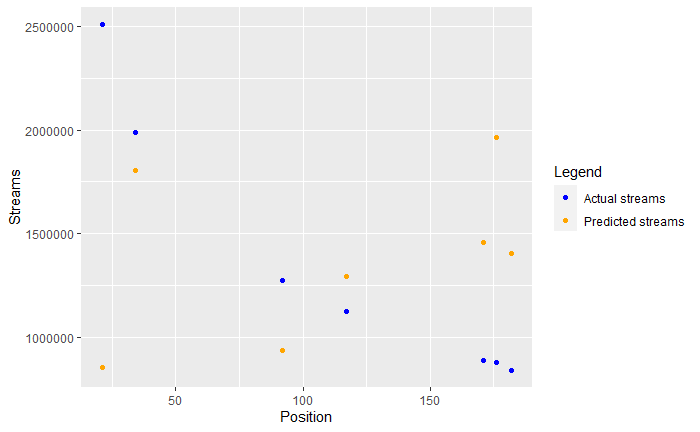

Despite the greater multiple R-squared value, the results are comparable to the other models shown below. The large differences in the number of streams predicted compared to the actual values show that the model is clearly not able to predict the number of streams based on the chosen track attributes.

#### Cluster 1 Results

```r
pred.c1 = tibble(pStreams = predict.lm(c1.lm, newdata = test_c1))
pTest_c1 <- test_c1 %>%
  cbind(pred.c1)%>%
  mutate(diff = Streams - pStreams) %>%
  select(Streams, pStreams, diff, everything())
pTest_c1 %>% arrange(-abs(diff))
```

| Streams | pStreams | diff | Position | Track Name | Artist | URL | id | danceability | energy | key | loudness | mode | speechiness | acousticness | instrumentalness | liveness | valence | tempo | type | uri | track_href | analysis_url | duration_ms | time_signature | cluster |
| --- | --- | --- | --- | --- | --- | --- | --- | --- | --- | --- | --- | --- | --- | --- | --- | --- | --- | --- | --- | --- | --- | --- | --- | --- | --- |
| 3266587 | 362690.2 | 2903896.81 | 11 | Lemonade (feat. Gunna, Don Toliver & NAV) | Internet Money | https://open.spotify.com/track/7hxHWCCAIIxFLCzvDgnQHX | 7hxHWCCAIIxFLCzvDgnQHX | 0.800 | 0.658 | 1 | -6.142 | 0 | 0.0790 | 0.25000 | 0.00e+00 | 0.1110 | 0.462 | 140.042 | audio_features | spotify:track:7hxHWCCAIIxFLCzvDgnQHX | https://api.spotify.com/v1/tracks/7hxHWCCAIIxFLCzvDgnQHX | https://api.spotify.com/v1/audio-analysis/7hxHWCCAIIxFLCzvDgnQHX | 195429 | 4 | 1 |
| 3031337 | 1093427.8 | 1937909.24 | 12 | Monster (Shawn Mendes & Justin Bieber) | Shawn Mendes | https://open.spotify.com/track/2Z8yfpFX0ZMavHkcIeHiO1 | 2Z8yfpFX0ZMavHkcIeHiO1 | 0.652 | 0.383 | 2 | -7.076 | 0 | 0.0516 | 0.06760 | 0.00e+00 | 0.0828 | 0.549 | 145.765 | audio_features | spotify:track:2Z8yfpFX0ZMavHkcIeHiO1 | https://api.spotify.com/v1/tracks/2Z8yfpFX0ZMavHkcIeHiO1 | https://api.spotify.com/v1/audio-analysis/2Z8yfpFX0ZMavHkcIeHiO1 | 178994 | 4 | 1 |
| 2544243 | 935821.5 | 1608421.46 | 19 | Prisoner (feat. Dua Lipa) | Miley Cyrus | https://open.spotify.com/track/2Oycxb8QbPkpHTo8ZrmG0B | 2Oycxb8QbPkpHTo8ZrmG0B | 0.781 | 0.670 | 3 | -3.912 | 0 | 0.0452 | 0.01030 | 0.00e+00 | 0.0761 | 0.595 | 127.990 | audio_features | spotify:track:2Oycxb8QbPkpHTo8ZrmG0B | https://api.spotify.com/v1/tracks/2Oycxb8QbPkpHTo8ZrmG0B | https://api.spotify.com/v1/audio-analysis/2Oycxb8QbPkpHTo8ZrmG0B | 169333 | 4 | 1 |
| 942145 | 2187870.6 | -1245725.59 | 157 | Go Crazy | Chris Brown | https://open.spotify.com/track/1IIKrJVP1C9N7iPtG6eOsK | 1IIKrJVP1C9N7iPtG6eOsK | 0.755 | 0.578 | 0 | -8.932 | 0 | 0.1450 | 0.31600 | 0.00e+00 | 0.2500 | 0.581 | 94.148 | audio_features | spotify:track:1IIKrJVP1C9N7iPtG6eOsK | https://api.spotify.com/v1/tracks/1IIKrJVP1C9N7iPtG6eOsK | https://api.spotify.com/v1/audio-analysis/1IIKrJVP1C9N7iPtG6eOsK | 176960 | 4 | 1 |
| 947181 | 2149088.5 | -1201907.50 | 154 | In Your Eyes | The Weeknd | https://open.spotify.com/track/7szuecWAPwGoV1e5vGu8tl | 7szuecWAPwGoV1e5vGu8tl | 0.667 | 0.719 | 7 | -5.371 | 0 | 0.0346 | 0.00285 | 8.10e-05 | 0.0736 | 0.717 | 100.021 | audio_features | spotify:track:7szuecWAPwGoV1e5vGu8tl | https://api.spotify.com/v1/tracks/7szuecWAPwGoV1e5vGu8tl | https://api.spotify.com/v1/audio-analysis/7szuecWAPwGoV1e5vGu8tl | 237520 | 4 | 1 |
| 1151155 | 2282308.4 | -1131153.39 | 110 | Mood Swings (feat. Lil Tjay) | Pop Smoke | https://open.spotify.com/track/5rZlwNFl01HqLWBQGryKSm | 5rZlwNFl01HqLWBQGryKSm | 0.480 | 0.602 | 10 | -6.335 | 0 | 0.3680 | 0.48700 | 0.00e+00 | 0.0848 | 0.269 | 179.798 | audio_features | spotify:track:5rZlwNFl01HqLWBQGryKSm | https://api.spotify.com/v1/tracks/5rZlwNFl01HqLWBQGryKSm | https://api.spotify.com/v1/audio-analysis/5rZlwNFl01HqLWBQGryKSm | 213333 | 4 | 1 |
| 2284391 | 1271670.0 | 1012721.01 | 25 | Hawái | Maluma | https://open.spotify.com/track/1yoMvmasuxZfqHEipJhRbp | 1yoMvmasuxZfqHEipJhRbp | 0.783 | 0.727 | 6 | -3.454 | 0 | 0.3890 | 0.18500 | 2.46e-05 | 0.0626 | 0.558 | 180.067 | audio_features | spotify:track:1yoMvmasuxZfqHEipJhRbp | https://api.spotify.com/v1/tracks/1yoMvmasuxZfqHEipJhRbp | https://api.spotify.com/v1/audio-analysis/1yoMvmasuxZfqHEipJhRbp | 199112 | 4 | 1 |
| 862250 | 1320195.6 | -457945.61 | 179 | I CAN'T STOP ME | TWICE | https://open.spotify.com/track/3apeXzypBMnUfYcZYNX6DH | 3apeXzypBMnUfYcZYNX6DH | 0.657 | 0.880 | 10 | -3.672 | 0 | 0.1020 | 0.12100 | 0.00e+00 | 0.4630 | 0.769 | 150.084 | audio_features | spotify:track:3apeXzypBMnUfYcZYNX6DH | https://api.spotify.com/v1/tracks/3apeXzypBMnUfYcZYNX6DH | https://api.spotify.com/v1/audio-analysis/3apeXzypBMnUfYcZYNX6DH | 205493 | 4 | 1 |
| 1235074 | 859632.0 | 375442.02 | 95 | Paradise (feat. Dermot Kennedy) | MEDUZA | https://open.spotify.com/track/6ft4hAq6yde8jPZY2i5zLr | 6ft4hAq6yde8jPZY2i5zLr | 0.632 | 0.595 | 8 | -7.644 | 0 | 0.0401 | 0.06890 | 0.00e+00 | 0.2090 | 0.435 | 124.114 | audio_features | spotify:track:6ft4hAq6yde8jPZY2i5zLr | https://api.spotify.com/v1/tracks/6ft4hAq6yde8jPZY2i5zLr | https://api.spotify.com/v1/audio-analysis/6ft4hAq6yde8jPZY2i5zLr | 167903 | 4 | 1 |
| 1005119 | 1298912.5 | -293793.54 | 139 | 120 | Bad Bunny | https://open.spotify.com/track/3KJ3opyV29269SXkPrc19l | 3KJ3opyV29269SXkPrc19l | 0.636 | 0.656 | 2 | -5.542 | 0 | 0.0676 | 0.45100 | 7.97e-06 | 0.2870 | 0.439 | 171.918 | audio_features | spotify:track:3KJ3opyV29269SXkPrc19l | https://api.spotify.com/v1/tracks/3KJ3opyV29269SXkPrc19l | https://api.spotify.com/v1/audio-analysis/3KJ3opyV29269SXkPrc19l | 151506 | 4 | 1 |

[output cut: 6 more lines]

Below is a plot of the predicted streams vs the actual streams to show the performance of our model predicting streams.

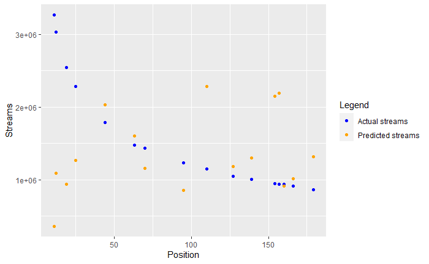

Like the other models, the large differences in the number of streams predicted compared to the actual values show that the model is clearly not able to predict the number of streams based on the chosen track attributes. This comment applies to the other models, which is why it is repeated.

#### Cluster 2 Results

```r
pred.c2 = tibble(pStreams = predict.lm(c2.lm, newdata = test_c2))
pTest_c2 <- test_c2 %>%
  cbind(pred.c2)%>%
  mutate(diff = Streams - pStreams) %>%
  select(Streams, pStreams, diff, everything())
pTest_c2 %>% arrange(-abs(diff))
```

| Streams | pStreams | diff | Position | Track Name | Artist | URL | id | danceability | energy | key | loudness | mode | speechiness | acousticness | instrumentalness | liveness | valence | tempo | type | uri | track_href | analysis_url | duration_ms | time_signature | cluster |
| --- | --- | --- | --- | --- | --- | --- | --- | --- | --- | --- | --- | --- | --- | --- | --- | --- | --- | --- | --- | --- | --- | --- | --- | --- | --- |
| 2193022 | 40497106.7 | -38304084.714 | 28 | It's the Most Wonderful Time of the Year | Andy Williams | https://open.spotify.com/track/1IcR6RlgvDczfvoWJSSY2A | 1IcR6RlgvDczfvoWJSSY2A | 0.234 | 0.526 | 2 | -11.656 | 1 | 0.0411 | 0.8710 | 2.34e-06 | 0.1220 | 0.649 | 201.739 | audio_features | spotify:track:1IcR6RlgvDczfvoWJSSY2A | https://api.spotify.com/v1/tracks/1IcR6RlgvDczfvoWJSSY2A | https://api.spotify.com/v1/audio-analysis/1IcR6RlgvDczfvoWJSSY2A | 151000 | 3 | 2 |
| 2425108 | 1197678.9 | 1227429.144 | 23 | Jingle Bell Rock | Bobby Helms | https://open.spotify.com/track/7vQbuQcyTflfCIOu3Uzzya | 7vQbuQcyTflfCIOu3Uzzya | 0.754 | 0.424 | 2 | -8.463 | 1 | 0.0363 | 0.6430 | 0.00e+00 | 0.0652 | 0.806 | 119.705 | audio_features | spotify:track:7vQbuQcyTflfCIOu3Uzzya | https://api.spotify.com/v1/tracks/7vQbuQcyTflfCIOu3Uzzya | https://api.spotify.com/v1/audio-analysis/7vQbuQcyTflfCIOu3Uzzya | 130973 | 4 | 2 |
| 930559 | 1887390.3 | -956831.301 | 161 | Real Shit (with benny blanco) | Juice WRLD | https://open.spotify.com/track/3uVPLtkmDu8pDkYEAVqbgS | 3uVPLtkmDu8pDkYEAVqbgS | 0.703 | 0.703 | 1 | -4.672 | 1 | 0.1330 | 0.6050 | 0.00e+00 | 0.1200 | 0.697 | 76.017 | audio_features | spotify:track:3uVPLtkmDu8pDkYEAVqbgS | https://api.spotify.com/v1/tracks/3uVPLtkmDu8pDkYEAVqbgS | https://api.spotify.com/v1/audio-analysis/3uVPLtkmDu8pDkYEAVqbgS | 183783 | 4 | 2 |
| 1436880 | 650752.1 | 786127.893 | 68 | Let It Snow! Let It Snow! Let It Snow! (with The B. Swanson Quartet) | Frank Sinatra | https://open.spotify.com/track/4kKdvXD0ez7jp1296JmAts | 4kKdvXD0ez7jp1296JmAts | 0.652 | 0.259 | 2 | -13.336 | 1 | 0.0595 | 0.9030 | 0.00e+00 | 0.3620 | 0.836 | 142.169 | audio_features | spotify:track:4kKdvXD0ez7jp1296JmAts | https://api.spotify.com/v1/tracks/4kKdvXD0ez7jp1296JmAts | https://api.spotify.com/v1/audio-analysis/4kKdvXD0ez7jp1296JmAts | 155453 | 4 | 2 |
| 1937835 | 1293673.2 | 644161.815 | 36 | Roses - Imanbek Remix | SAINt JHN | https://open.spotify.com/track/5f5tMrP3ZZbNtiLIHKOQLS | 5f5tMrP3ZZbNtiLIHKOQLS | 0.769 | 0.719 | 8 | -5.472 | 1 | 0.0474 | 0.0143 | 7.77e-03 | 0.3590 | 0.863 | 121.955 | audio_features | spotify:track:5f5tMrP3ZZbNtiLIHKOQLS | https://api.spotify.com/v1/tracks/5f5tMrP3ZZbNtiLIHKOQLS | https://api.spotify.com/v1/audio-analysis/5f5tMrP3ZZbNtiLIHKOQLS | 176867 | 4 | 2 |
| 823479 | 1401200.4 | -577721.362 | 185 | Mad at Disney | salem ilese | https://open.spotify.com/track/7aGyRfJWtLqgJaZoG9lJhE | 7aGyRfJWtLqgJaZoG9lJhE | 0.738 | 0.621 | 0 | -7.313 | 1 | 0.0486 | 0.4240 | 7.39e-06 | 0.6920 | 0.715 | 113.968 | audio_features | spotify:track:7aGyRfJWtLqgJaZoG9lJhE | https://api.spotify.com/v1/tracks/7aGyRfJWtLqgJaZoG9lJhE | https://api.spotify.com/v1/audio-analysis/7aGyRfJWtLqgJaZoG9lJhE | 136839 | 4 | 2 |
| 1021966 | 1559207.4 | -537241.400 | 135 | SORRY PAPI | Bad Bunny | https://open.spotify.com/track/5jZ32WOU7sqzDYbzINwMUk | 5jZ32WOU7sqzDYbzINwMUk | 0.612 | 0.561 | 1 | -6.054 | 1 | 0.0851 | 0.0601 | 0.00e+00 | 0.1450 | 0.393 | 191.911 | audio_features | spotify:track:5jZ32WOU7sqzDYbzINwMUk | https://api.spotify.com/v1/tracks/5jZ32WOU7sqzDYbzINwMUk | https://api.spotify.com/v1/audio-analysis/5jZ32WOU7sqzDYbzINwMUk | 163053 | 4 | 2 |
| 951645 | 1459212.5 | -507567.464 | 152 | Hecha Pa' Mi | Boza | https://open.spotify.com/track/3VvA1wSxukMLsvXoXtlwWx | 3VvA1wSxukMLsvXoXtlwWx | 0.725 | 0.756 | 4 | -5.013 | 1 | 0.0572 | 0.3620 | 6.85e-04 | 0.1030 | 0.828 | 100.070 | audio_features | spotify:track:3VvA1wSxukMLsvXoXtlwWx | https://api.spotify.com/v1/tracks/3VvA1wSxukMLsvXoXtlwWx | https://api.spotify.com/v1/audio-analysis/3VvA1wSxukMLsvXoXtlwWx | 186133 | 4 | 2 |
| 1223979 | 1595550.9 | -371571.878 | 98 | Tusa | KAROL G | https://open.spotify.com/track/7k4t7uLgtOxPwTpFmtJNTY | 7k4t7uLgtOxPwTpFmtJNTY | 0.803 | 0.715 | 2 | -3.280 | 1 | 0.2980 | 0.2950 | 1.34e-04 | 0.0574 | 0.574 | 101.085 | audio_features | spotify:track:7k4t7uLgtOxPwTpFmtJNTY | https://api.spotify.com/v1/tracks/7k4t7uLgtOxPwTpFmtJNTY | https://api.spotify.com/v1/audio-analysis/7k4t7uLgtOxPwTpFmtJNTY | 200960 | 4 | 2 |
| 1008057 | 1362877.3 | -354820.301 | 138 | All Girls Are The Same | Juice WRLD | https://open.spotify.com/track/4VXIryQMWpIdGgYR4TrjT1 | 4VXIryQMWpIdGgYR4TrjT1 | 0.671 | 0.529 | 0 | -7.226 | 1 | 0.3070 | 0.0769 | 3.35e-04 | 0.0856 | 0.203 | 161.989 | audio_features | spotify:track:4VXIryQMWpIdGgYR4TrjT1 | https://api.spotify.com/v1/tracks/4VXIryQMWpIdGgYR4TrjT1 | https://api.spotify.com/v1/audio-analysis/4VXIryQMWpIdGgYR4TrjT1 | 165820 | 4 | 2 |

[output cut: 8 more lines]

Below is a plot of the predicted streams vs the actual streams to show the performance of our model predicting streams.

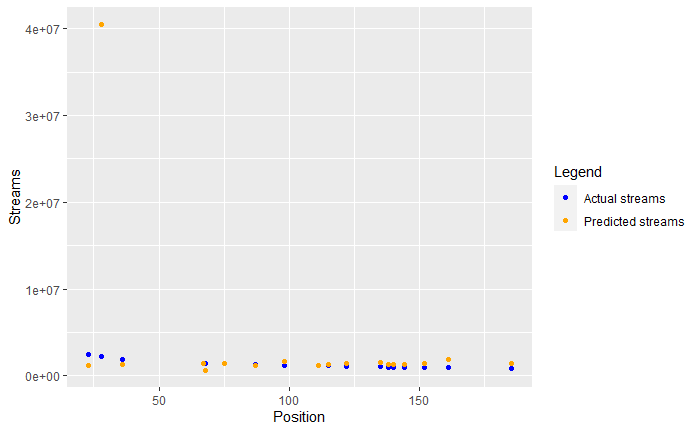

Like the other models, the large differences in the number of streams predicted compared to the actual values show that the model is clearly not able to predict the number of streams based on the chosen track attributes. This comment applies to the other models, which is why it is repeated.

#### No Clusters Results

```r
pred.none = tibble(pStreams = predict.lm(none.lm, newdata = test_data))
pTest_data <- test_data %>%
  cbind(pred.none)%>%
  mutate(diff = Streams - pStreams) %>%
  select(Streams, pStreams, diff, everything())
pTest_data %>% arrange(-abs(diff))
```

| Streams | pStreams | diff | Position | Track Name | Artist | URL | id | danceability | energy | key | loudness | mode | speechiness | acousticness | instrumentalness | liveness | valence | tempo | type | uri | track_href | analysis_url | duration_ms | time_signature | cluster |
| --- | --- | --- | --- | --- | --- | --- | --- | --- | --- | --- | --- | --- | --- | --- | --- | --- | --- | --- | --- | --- | --- | --- | --- | --- | --- |
| 3266587 | 1396911 | 1869676.420 | 11 | Lemonade (feat. Gunna, Don Toliver & NAV) | Internet Money | https://open.spotify.com/track/7hxHWCCAIIxFLCzvDgnQHX | 7hxHWCCAIIxFLCzvDgnQHX | 0.800 | 0.658 | 1 | -6.142 | 0 | 0.0790 | 0.25000 | 0.00e+00 | 0.1110 | 0.4620 | 140.042 | audio_features | spotify:track:7hxHWCCAIIxFLCzvDgnQHX | https://api.spotify.com/v1/tracks/7hxHWCCAIIxFLCzvDgnQHX | https://api.spotify.com/v1/audio-analysis/7hxHWCCAIIxFLCzvDgnQHX | 195429 | 4 | 1 |
| 3031337 | 1257989 | 1773348.269 | 12 | Monster (Shawn Mendes & Justin Bieber) | Shawn Mendes | https://open.spotify.com/track/2Z8yfpFX0ZMavHkcIeHiO1 | 2Z8yfpFX0ZMavHkcIeHiO1 | 0.652 | 0.383 | 2 | -7.076 | 0 | 0.0516 | 0.06760 | 0.00e+00 | 0.0828 | 0.5490 | 145.765 | audio_features | spotify:track:2Z8yfpFX0ZMavHkcIeHiO1 | https://api.spotify.com/v1/tracks/2Z8yfpFX0ZMavHkcIeHiO1 | https://api.spotify.com/v1/audio-analysis/2Z8yfpFX0ZMavHkcIeHiO1 | 178994 | 4 | 1 |
| 2544243 | 1421204 | 1123039.316 | 19 | Prisoner (feat. Dua Lipa) | Miley Cyrus | https://open.spotify.com/track/2Oycxb8QbPkpHTo8ZrmG0B | 2Oycxb8QbPkpHTo8ZrmG0B | 0.781 | 0.670 | 3 | -3.912 | 0 | 0.0452 | 0.01030 | 0.00e+00 | 0.0761 | 0.5950 | 127.990 | audio_features | spotify:track:2Oycxb8QbPkpHTo8ZrmG0B | https://api.spotify.com/v1/tracks/2Oycxb8QbPkpHTo8ZrmG0B | https://api.spotify.com/v1/audio-analysis/2Oycxb8QbPkpHTo8ZrmG0B | 169333 | 4 | 1 |
| 2509375 | 1430166 | 1079208.748 | 21 | Lonely (with benny blanco) | Justin Bieber | https://open.spotify.com/track/4y4spB9m0Q6026KfkAvy9Q | 4y4spB9m0Q6026KfkAvy9Q | 0.631 | 0.239 | 11 | -7.071 | 0 | 0.0398 | 0.86400 | 0.00e+00 | 0.1160 | 0.0927 | 79.859 | audio_features | spotify:track:4y4spB9m0Q6026KfkAvy9Q | https://api.spotify.com/v1/tracks/4y4spB9m0Q6026KfkAvy9Q | https://api.spotify.com/v1/audio-analysis/4y4spB9m0Q6026KfkAvy9Q | 149297 | 4 | 0 |
| 2425108 | 1569003 | 856104.709 | 23 | Jingle Bell Rock | Bobby Helms | https://open.spotify.com/track/7vQbuQcyTflfCIOu3Uzzya | 7vQbuQcyTflfCIOu3Uzzya | 0.754 | 0.424 | 2 | -8.463 | 1 | 0.0363 | 0.64300 | 0.00e+00 | 0.0652 | 0.8060 | 119.705 | audio_features | spotify:track:7vQbuQcyTflfCIOu3Uzzya | https://api.spotify.com/v1/tracks/7vQbuQcyTflfCIOu3Uzzya | https://api.spotify.com/v1/audio-analysis/7vQbuQcyTflfCIOu3Uzzya | 130973 | 4 | 2 |
| 2284391 | 1452140 | 832250.793 | 25 | Hawái | Maluma | https://open.spotify.com/track/1yoMvmasuxZfqHEipJhRbp | 1yoMvmasuxZfqHEipJhRbp | 0.783 | 0.727 | 6 | -3.454 | 0 | 0.3890 | 0.18500 | 2.46e-05 | 0.0626 | 0.5580 | 180.067 | audio_features | spotify:track:1yoMvmasuxZfqHEipJhRbp | https://api.spotify.com/v1/tracks/1yoMvmasuxZfqHEipJhRbp | https://api.spotify.com/v1/audio-analysis/1yoMvmasuxZfqHEipJhRbp | 199112 | 4 | 1 |
| 840751 | 1665339 | -824587.564 | 182 | Perfect | Ed Sheeran | https://open.spotify.com/track/0tgVpDi06FyKpA1z0VMD4v | 0tgVpDi06FyKpA1z0VMD4v | 0.599 | 0.448 | 8 | -6.312 | 1 | 0.0232 | 0.16300 | 0.00e+00 | 0.1060 | 0.1680 | 95.050 | audio_features | spotify:track:0tgVpDi06FyKpA1z0VMD4v | https://api.spotify.com/v1/tracks/0tgVpDi06FyKpA1z0VMD4v | https://api.spotify.com/v1/audio-analysis/0tgVpDi06FyKpA1z0VMD4v | 263400 | 3 | 0 |
| 823479 | 1548525 | -725046.180 | 185 | Mad at Disney | salem ilese | https://open.spotify.com/track/7aGyRfJWtLqgJaZoG9lJhE | 7aGyRfJWtLqgJaZoG9lJhE | 0.738 | 0.621 | 0 | -7.313 | 1 | 0.0486 | 0.42400 | 7.39e-06 | 0.6920 | 0.7150 | 113.968 | audio_features | spotify:track:7aGyRfJWtLqgJaZoG9lJhE | https://api.spotify.com/v1/tracks/7aGyRfJWtLqgJaZoG9lJhE | https://api.spotify.com/v1/audio-analysis/7aGyRfJWtLqgJaZoG9lJhE | 136839 | 4 | 2 |
| 951645 | 1623871 | -672225.778 | 152 | Hecha Pa' Mi | Boza | https://open.spotify.com/track/3VvA1wSxukMLsvXoXtlwWx | 3VvA1wSxukMLsvXoXtlwWx | 0.725 | 0.756 | 4 | -5.013 | 1 | 0.0572 | 0.36200 | 6.85e-04 | 0.1030 | 0.8280 | 100.070 | audio_features | spotify:track:3VvA1wSxukMLsvXoXtlwWx | https://api.spotify.com/v1/tracks/3VvA1wSxukMLsvXoXtlwWx | https://api.spotify.com/v1/audio-analysis/3VvA1wSxukMLsvXoXtlwWx | 186133 | 4 | 2 |
| 1003128 | 1635104 | -631976.147 | 140 | Ice Cream (with Selena Gomez) | BLACKPINK | https://open.spotify.com/track/4JUPEh2DVSXFGExu4Uxevz | 4JUPEh2DVSXFGExu4Uxevz | 0.785 | 0.719 | 4 | -3.886 | 1 | 0.3540 | 0.03740 | 1.08e-04 | 0.0519 | 0.8870 | 159.953 | audio_features | spotify:track:4JUPEh2DVSXFGExu4Uxevz | https://api.spotify.com/v1/tracks/4JUPEh2DVSXFGExu4Uxevz | https://api.spotify.com/v1/audio-analysis/4JUPEh2DVSXFGExu4Uxevz | 175813 | 4 | 2 |

[output cut: 31 more lines]

Below is a plot of the predicted streams vs the actual streams to show the performance of our model predicting streams for all of the data

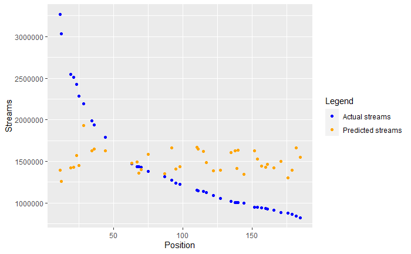

Like the other models, the large differences in the number of streams predicted compared to the actual values show that the model is clearly not able to predict the number of streams based on the chosen track attributes. This comment applies to the other models, which is why it is repeated.

## Part V: Results and Conclustion

Question: Can we predict the number of streams a Top 200 song on Spotify will get by finding clusters within the data?

Answer: No, we are not able to predict the number of streams such a song would get on Spotify from clusters based on a song’s characteristics (as determined by Spotify).

### Limitations of Model and Results

- Only top 200 songs are used, meaning that using the model for a song not in the top 200 would be outside the scope of these models
- Other more sophisticated regression methods beyond linear regression may yield different results
- There are other models that can be explored with the given data set
- Models rely on the quality of the predictors. How accurate are Spotify’s track attribute metrics? How are they measured?
- The k-means algorithm used an initializer for the purpose of keeping results consistent across runs (so that cluster 0 would always be cluster 0 instead of cluster 2, for instance, as such labels are arbitrarily decided). Results vary less than they should because of this.
- The k-means algorithm was the only clustering algorithm explored. Would another clustering method have yielded better results?
- Results are based on current data. The consistency of these results cannot be guaranteed over time. Tomorrow’s data could be predicted either better or worse by these methods.

# In Conclusion.

A better data set might be able to answer this question with greater accuracy; however, given this top 200 data set with audio features from Spotify, it appears that we cannot predict the number of streams a song would get on Spotify when utilizing clustering based on Spotify’s audio features.